# Regression algorithms

Regression algorithms are a type of machine learning algorithm used to predict numerical values based on input data. Regression algorithms attempt to find a relationship between the input variables and the output variable by fitting a mathematical model to the data. The goal of regression is to find a mathematical relationship between the input features and the target variable that can be used to make accurate predictions on new, unseen data.

[figure not shown]

There are many different types of regression algorithms, including:

1. **Linear regression:** Linear regression is a simple and widely used algorithm. It assumes a linear relationship between the independent variables and the target variable. The algorithm estimates the coefficients of the linear equation that best fits the data. The equation can be of the form

   $y = mx + b$,

   where $y$ is the target variable, $x$ is the input feature, $m$ is the slope, and $b$ is the intercept.

   **Example:** applications include predicting housing prices based on features like square footage and number of bedrooms, or estimating sales based on advertising expenditure.
2. **Logistic regression:** Logistic regression is a popular algorithm used for binary classification problems, where the target variable has two possible outcomes (e.g., yes/no, true/false, 0/1). Despite its name, logistic regression is a classification algorithm, not a regression algorithm. It models the relationship between the independent variables (input features) and the binary target variable using the logistic function, also known as the sigmoid function.

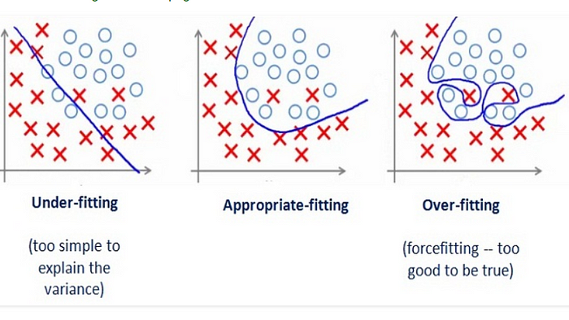

   **Example:** predicting whether a customer will churn (i.e., stop doing business with a company) based on their demographic information and purchase history.
3. **Polynomial regression:** Polynomial regression is an extension of linear regression where the relationship between the variables is modeled using a polynomial equation. This allows for more flexibility in capturing nonlinear relationships between the input features and the target variable. It involves adding polynomial terms, such as $x^2$ or $x^3$, to the linear equation. Polynomial regression is useful when the data exhibits curvilinear patterns.

   **Example:** predicting the yield of a crop based on factors such as temperature, humidity, and rainfall.
4. **Ridge regression:** Ridge regression is a regularization technique that addresses the issue of overfitting in linear regression. It adds a penalty term to the linear regression equation to control the complexity of the model. This penalty term helps prevent the coefficients from becoming too large, reducing the model's sensitivity to the training data. Ridge regression is particularly useful when dealing with high-dimensional data or when multicollinearity (high correlation) exists among the input features.

   **Example:** predicting the price of a stock based on financial indicators such as earnings per share and price-to-earnings ratio.
5. **Lasso regression:** Lasso regression, similar to ridge regression, is a regularization technique used to combat overfitting. It adds a penalty term to the linear regression equation, but in this case, it uses the L1 norm of the coefficients as the penalty. Lasso regression has a feature selection property that can drive some coefficients to zero, effectively performing automatic feature selection. This makes it useful when dealing with datasets with many features or when looking to identify the most influential variables.

   **Example:** predicting the likelihood of a customer purchasing a product based on their browsing and purchase history on a website.
6. **Elastic Net regression:** ElasticNet regression combines both ridge and lasso regularization techniques. It adds a penalty term that is a linear combination of the L1 (lasso) and L2 (ridge) norms of the coefficients. This hybrid approach allows for feature selection while also providing stability and reducing the impact of multicollinearity. ElasticNet regression is useful when there are many correlated features and the goal is to both select relevant features and mitigate multicollinearity.

   **Example:** predicting the demand for a product based on factors such as price, advertising spend, and competitor activity.

There are many other regression algorithms as well, and the choice of algorithm depends on the specific problem and the characteristics of the data.

**Example:**

- finance,
- healthcare,
- manufacturing
- Defence and space

## Applications of Regression algorithms

### 1. In Finance sector:

- **Risk management:** Regression algorithms can be used to analyze historical market data to identify patterns and trends in asset prices, which can help financial institutions to better understand and manage risks associated with their portfolios.
- **Portfolio optimization:** Regression algorithms can be used to optimize the allocation of assets in a portfolio to maximize returns while minimizing risk. This involves using historical data to identify correlations between asset prices and building a model to predict future returns.
- **Credit scoring:** Regression algorithms can be used to analyze borrower data such as credit scores, income, and employment history, to predict the likelihood of default on a loan. This information can be used by lenders to make more informed lending decisions.
- **Trading strategies:** Regression algorithms can be used to analyze market data and identify profitable trading strategies. For example, a regression model could be used to predict the price of a stock based on its historical performance, and this information could be used to make buy or sell decisions.
- **Financial forecasting:** Regression algorithms can be used to forecast financial performance metrics such as revenue, profits, and cash flow, based on historical data and other factors such as market trends and economic indicators. This information can be used by financial analysts to make informed investment recommendations.

### 2. In healthcare sector:

- **Predicting patient outcomes:** Regression algorithms can be used to predict outcomes such as mortality, readmission, and length of stay for patients based on factors such as age, gender, diagnosis, and comorbidities. This information can help healthcare providers make more informed decisions about patient care and resource allocation.
- **Predicting disease progression:** Regression algorithms can be used to predict the progression of diseases such as cancer, Alzheimer's, and Parkinson's based on biomarkers, genetic information, and other factors. This information can help with early detection and personalized treatment plans.
- **Forecasting healthcare costs:** Regression algorithms can be used to forecast healthcare costs for individuals and populations based on factors such as age, gender, and medical history. This information can be used by insurance companies and policymakers to make more informed decisions about coverage and reimbursement.
- **Analyzing clinical trials:** Regression algorithms can be used to analyze data from clinical trials to determine the efficacy and safety of new treatments. This information can help drug developers make decisions about which drugs to advance to the next phase of development.
- **Predicting disease outbreaks:** Regression algorithms can be used to predict disease outbreaks based on factors such as weather patterns, population density, and vaccination rates. This information can help public health officials make decisions about resource allocation and disease prevention strategies.

### 3. In manufacturing sector:

- **Quality Control:** Regression algorithms can be used to monitor the quality of manufactured products by analyzing the relationship between the input variables (such as the raw materials used, the manufacturing process parameters) and the output variables (such as the product quality metrics). This helps in identifying factors that affect the quality of the product and optimizing the manufacturing process accordingly.
- **Predictive Maintenance:** Regression algorithms can be used to predict the remaining useful life of manufacturing equipment based on factors such as operating conditions, maintenance history, and sensor data. This helps in scheduling maintenance activities in advance, reducing downtime, and improving equipment reliability.
- **Process Optimization:** Regression algorithms can be used to optimize the manufacturing process by analyzing the relationship between the input variables (such as the process parameters, raw materials) and the output variables (such as product yield, production rate). This helps in identifying the optimal process settings that result in the highest quality products with minimal waste.
- **Supply Chain Management:** Regression algorithms can be used to forecast demand for raw materials and finished products based on historical sales data, economic trends, and market conditions. This helps in improving supply chain planning, reducing inventory costs, and avoiding stockouts.
- **Root Cause Analysis:** Regression algorithms can be used to identify the root cause of defects or quality issues in the manufacturing process by analyzing the relationship between input variables and output variables. This helps in identifying the factors that contribute to defects and implementing corrective actions to prevent them from occurring in the future.

### 4. In Space & Defence sector:

- **Trajectory prediction:** In the space sector, regression algorithms can be used to predict the trajectory of spacecraft, satellites, and other objects in orbit. This can help with mission planning, collision avoidance, and re-entry planning.
- **Missile guidance:** In the defense sector, regression algorithms can be used to guide missiles to their targets. By analyzing data such as the target's speed, direction, and distance, a regression algorithm can predict the missile's trajectory and make adjustments to ensure it hits the target.
- **Signal processing:** Regression algorithms can also be used in the analysis of signals received from space. For example, they can be used to estimate the direction of arrival of signals from space, which can help with tasks such as tracking satellites and detecting and identifying space debris.
- **Target tracking:** In the defense sector, regression algorithms can be used to track the movement of targets such as vehicles and aircraft. By analyzing data such as the target's speed, direction, and radar signature, a regression algorithm can predict its future position and velocity, which can help with intercepting the target.
- **Image analysis:** Regression algorithms can also be used in the analysis of images and video data from space and defense applications. For example, they can be used to estimate the size and shape of objects in images, detect anomalies, and identify targets.

These are just a few examples of the applications of regression algorithms in various sector. As technology advances and more data becomes available, we can expect to see even more applications of these algorithms in these fields.

## Terminologies Related to the Regression Analysis

1. **Dependent variable:** The variable being predicted or explained by the regression analysis. It is also called the response variable or outcome variable.
2. **Independent variable:** The variable that is used to predict or explain the dependent variable. It is also called the predictor variable or explanatory variable.
3. **Simple linear regression:** A regression analysis that involves only one independent variable.
4. **Multiple linear regression:** A regression analysis that involves two or more independent variables.
5. **Coefficient:** The value that represents the slope of the regression line. It indicates the amount by which the dependent variable changes when the independent variable changes by one unit.
6. **Intercept:** The value of the dependent variable when all independent variables are set to zero. It represents the starting point of the regression line.
7. **Residual:** The difference between the actual value of the dependent variable and the predicted value from the regression line.
8. **R-squared:** A measure of how well the regression line fits the data. It represents the proportion of the variance in the dependent variable that is explained by the independent variable(s).
9. **Overfitting:** When a regression model is too complex and fits the training data too closely, it may not generalize well to new data.
10. **Underfitting:** When a regression model is too simple and does not fit the training data well enough, it may not capture the underlying relationships between the variables.

These are some common terminologies related to regression analysis, and there may be others depending on the specific context and type of regression being used.

## Why do we use Regression Analysis?

Regression analysis is a statistical method used to examine the relationship between a dependent variable and one or more independent variables. It is used for a variety of purposes, including:

1. **Prediction:** Regression analysis can be used to predict the values of the dependent variable based on the values of the independent variables. For example, if we want to predict the sales of a product based on advertising expenditure and the size of the market, we can use regression analysis to determine the relationship between these variables and predict the sales based on the values of the independent variables.
2. **Hypothesis testing:** Regression analysis can be used to test hypotheses about the relationship between the dependent and independent variables. For example, we can test whether there is a significant relationship between smoking and lung cancer by using regression analysis.
3. **Control variables:** Regression analysis can be used to control for other variables that may affect the relationship between the dependent and independent variables. For example, if we want to examine the relationship between income and health, we may want to control for variables such as age, gender, and education.
4. **Forecasting:** Regression analysis can be used to forecast future trends based on historical data. For example, we can use regression analysis to forecast the demand for a product based on past sales data and other relevant variables.

Overall, regression analysis is a useful tool for analyzing and understanding the relationship between variables and for making predictions and informed decisions based on that relationship.

# Reference

1. https://www.javatpoint.com/regression-analysis-in-machine-learning
2. Machine Learning, using Python Manaranjan Pradhan | U Dinesh Kumar